# Kinship LR Simulation Analysis

Generated Analysis Report

January 16, 2026

# 1 Overview

This report analyzes kinship likelihood ratio (LR) simulations comparing two tested hypotheses:

1. **Parent-Child Hypothesis**: LR for testing if pairs are parent-child vs unrelated
2. **Full-Siblings Hypothesis**: LR for testing if pairs are full siblings vs unrelated

For each hypothesis, we examine performance across:

- **True positives**: Correctly identifying the target relationship
- **Related false positives**: Other relatives incorrectly exceeding threshold (e.g., half-siblings misidentified as full siblings)
- **Unrelated false positives**: Unrelated pairs incorrectly exceeding threshold

# 2 Data Loading and Preprocessing

```r
# Generate toy simulation data for testing the analysis pipeline
set.seed(42)

# Define factor levels
population_order <- c("all", "AfAm", "Asian", "Cauc", "Hispanic")
relationship_order <- c("parent_child", "full_siblings", "half_siblings",
                        "cousins", "second_cousins", "unrelated")
loci_set_order <- c("core_13", "identifiler_15", "expanded_20",
                    "supplementary", "autosomal_29")

# ONLY these two hypotheses are tested
tested_hypotheses <- c("parent_child", "full_siblings")

# Number of loci in each set
loci_counts <- c(
  "core_13" = 13,
  "identifiler_15" = 15,
  "expanded_20" = 20,
  "supplementary" = 23,
  "autosomal_29" = 29
)

# Mean per-locus log10(LR) matrix for the TWO tested hypotheses only
mean_log10_lr_matrix <- list(
  # Testing PARENT-CHILD hypothesis
  parent_child = c(
    "parent_child" = 0.40,      # True positive
    "full_siblings" = 0.10,     # Related FP (siblings look somewhat like PC)
    "half_siblings" = -0.05,    # Related FP
    "cousins" = -0.25,          # Related FP
    "second_cousins" = -0.30,   # Related FP
    "unrelated" = -0.35         # Unrelated FP
  ),
  # Testing FULL-SIBLING hypothesis
  full_siblings = c(
    "parent_child" = 0.35,      # Related FP (PC looks like FS)
    "full_siblings" = 0.25,     # True positive
    "half_siblings" = 0.063,    # Related FP - POSITIVE! (key finding)
    "cousins" = -0.232,         # Related FP
    "second_cousins" = -0.283,  # Related FP
    "unrelated" = -0.340        # Unrelated FP
  )
)

# SD of per-locus log10(LR)
sd_log10_lr_per_locus <- 0.20

# Population effects (slight variation by ancestry)
pop_effects <- c(
  "all" = 0,
  "AfAm" = 0.015,
  "Asian" = -0.012,
  "Cauc" = 0.008,
  "Hispanic" = -0.008
)

n_pairs <- params$n_pairs_per_group

# Generate data - ONLY for parent_child and full_siblings hypotheses
generate_toy_data <- function() {
  all_data <- list()

  for (pop in population_order) {
    for (known_rel in relationship_order) {
      for (tested_rel in tested_hypotheses) {  # Only PC and FS hypotheses
        for (loci_set in loci_set_order) {
          n_loci <- loci_counts[loci_set]

          # Get mean per-locus LR for this known/tested combination
          mean_per_locus <- mean_log10_lr_matrix[[tested_rel]][known_rel]
          sd_per_locus <- sd_log10_lr_per_locus

          # Add population effect
          pop_effect <- pop_effects[pop]

          # Combined LR is sum of per-locus log10(LR)
          mean_combined <- n_loci * (mean_per_locus + pop_effect)
          sd_combined <- sqrt(n_loci) * sd_per_locus

          log10_lr <- rnorm(n_pairs, mean = mean_combined, sd = sd_combined)
          combined_lr <- 10^log10_lr

          group_data <- data.table(
            batch_id = 1,
            pair_id = 1:n_pairs,
            population = pop,
            known_relationship = known_rel,
            tested_relationship = tested_rel,
            tested_population = pop,
            loci_set = loci_set,
            combined_LR = combined_lr,
            is_correct_pop = TRUE
          )

          all_data[[length(all_data) + 1]] <- group_data
        }
      }
    }
  }

  rbindlist(all_data)
}

if (params$use_toy_data) {
  cat("Generating toy simulation data...\n")
  all_combined <- generate_toy_data()
  cat("Generated", nrow(all_combined), "rows of toy data\n")
} else {
  cat("Loading data from:", params$input_file, "\n")
  all_combined <- readRDS(params$input_file)
  setDT(all_combined)
}
```

```
## Loading data from: ../output/lr_analysis_20251219/combined_LR_all.rds
```

```r
# data summary for toy data
#cat("Total rows:", nrow(all_combined), "\n")
#cat("Unique pairs per group:", params$n_pairs_per_group, "\n")
```

```r
# Filter dataframe to only the two tested hypotheses - necessary for big sim dataset
all_combined <- all_combined[tested_relationship %in% tested_hypotheses]

# Filter dataframe to only correct population - used the correct population allele freq
all_combined <- all_combined[is_correct_pop == TRUE]
```

```r
relationship_labels <- c(
  "parent_child" = "Parent-Child",
  "full_siblings" = "Full Siblings",
  "half_siblings" = "Half Siblings",
  "cousins" = "Cousins",
  "second_cousins" = "Second Cousins",
  "unrelated" = "Unrelated"
)

loci_set_labels <- c(
  "core_13" = "Core 13",
  "identifiler_15" = "Identifiler 15",
  "expanded_20" = "Expanded 20",
  "supplementary" = "Supplementary 23",
  "autosomal_29" = "Autosomal 29"
)

population_labels <- c(
  "all" = "All Populations",
  "AfAm" = "African American",
  "Asian" = "Asian",
  "Cauc" = "Caucasian",
  "Hispanic" = "Hispanic"
)


all_combined[, `:=`(
  population = factor(population, levels = population_order),
  tested_population = factor(tested_population, levels = population_order),
  known_relationship = factor(known_relationship, levels = relationship_order),
  tested_relationship = factor(tested_relationship, levels = tested_hypotheses),
  loci_set = factor(loci_set, levels = loci_set_order)
)]

# Add log10_LR column
all_combined[, log10_LR := log10(pmax(combined_LR, 1e-20))]

population_colors <- c(
  "all" = "#FF7F00",
  "AfAm" = "#E41A1C",
  "Asian" = "#377EB8",
  "Cauc" = "#4DAF4A",
  "Hispanic" = "#984EA3"
)

relationship_colors <- c(
  "parent_child" = "#1b9e77",
  "full_siblings" = "#d95f02",
  "half_siblings" = "#7570b3",
  "cousins" = "#e7298a",
  "second_cousins" = "#66a61e",
  "unrelated" = "#666666"
)
```

## 2.1 Data Summary

```r
# Show counts by population and known relationship
data_summary <- all_combined[, .(
  n_pairs = uniqueN(paste(batch_id, pair_id)),
  n_tested_hypotheses = uniqueN(tested_relationship),
  n_loci_sets = uniqueN(loci_set)
), by = .(population, known_relationship)]

data_summary_wide <- dcast(data_summary, known_relationship ~ population,
                           value.var = "n_pairs")

kable(data_summary_wide,
      caption = "Number of simulated pairs by population and known relationship<br>For each tested hypothesis:Parent-Child, Full-Siblings",
      format.args = list(big.mark = ",", scientific = FALSE)) %>%
  kable_styling(bootstrap_options = c("striped", "hover", "condensed"))
```

Number of simulated pairs by population and known relationship For each tested hypothesis:Parent-Child, Full-Siblings

| known_relationship | all | AfAm | Asian | Cauc | Hispanic |
| --- | --- | --- | --- | --- | --- |
| parent_child | 20,000 | 20,000 | 20,000 | 20,000 | 20,000 |
| full_siblings | 20,000 | 20,000 | 20,000 | 20,000 | 20,000 |
| half_siblings | 20,000 | 20,000 | 20,000 | 20,000 | 20,000 |
| cousins | 20,000 | 20,000 | 20,000 | 20,000 | 20,000 |
| second_cousins | 20,000 | 20,000 | 20,000 | 20,000 | 20,000 |
| unrelated | 100,000 | 100,000 | 100,000 | 100,000 | 100,000 |

# 3 Combined LR Distributions

## 3.1 Parent-Child Hypothesis

Testing: Are these pairs parent-child vs unrelated?

### 3.1.1 All Populations Combined

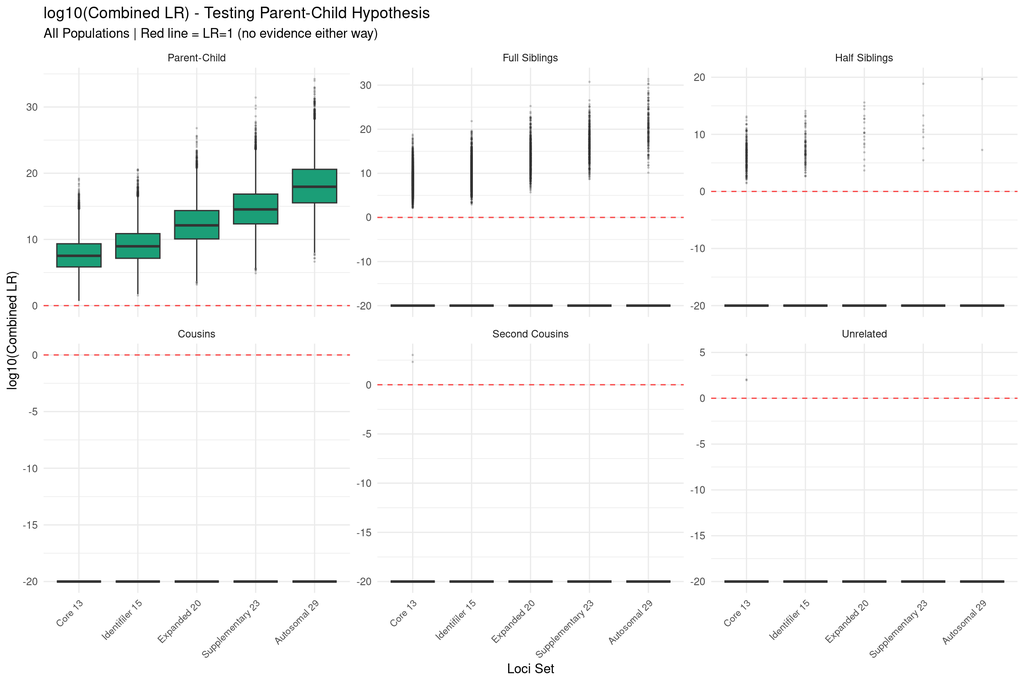

```r
plot_lr_by_hypothesis <- function(data, tested_hyp, pop_filter = NULL) {
  subset_data <- data[tested_relationship == tested_hyp]
  if (!is.null(pop_filter)) {
    subset_data <- subset_data[population == pop_filter]
  }

  title_pop <- if (is.null(pop_filter)) "All Populations" else population_labels[pop_filter]

  ggplot(subset_data, aes(x = loci_set, y = log10_LR, fill = known_relationship)) +
    geom_boxplot(outlier.size = 0.3, outlier.alpha = 0.2) +
    facet_wrap(~known_relationship, scales = "free_y", ncol = 3,
               labeller = labeller(known_relationship = relationship_labels)) +
    scale_fill_manual(values = relationship_colors, guide = "none") +
    scale_x_discrete(labels = loci_set_labels) +
    geom_hline(yintercept = 0, linetype = "dashed", color = "red", alpha = 0.7) +
    labs(
      title = paste("log10(Combined LR) - Testing", relationship_labels[tested_hyp], "Hypothesis"),
      subtitle = paste(title_pop, "| Red line = LR=1 (no evidence either way)"),
      x = "Loci Set",
      y = "log10(Combined LR)"
    ) +
    theme_minimal() +
    theme(axis.text.x = element_text(angle = 45, hjust = 1, size = 8))
}

plot_lr_by_hypothesis(all_combined, "parent_child", "all")
```

### 3.1.2 By Population

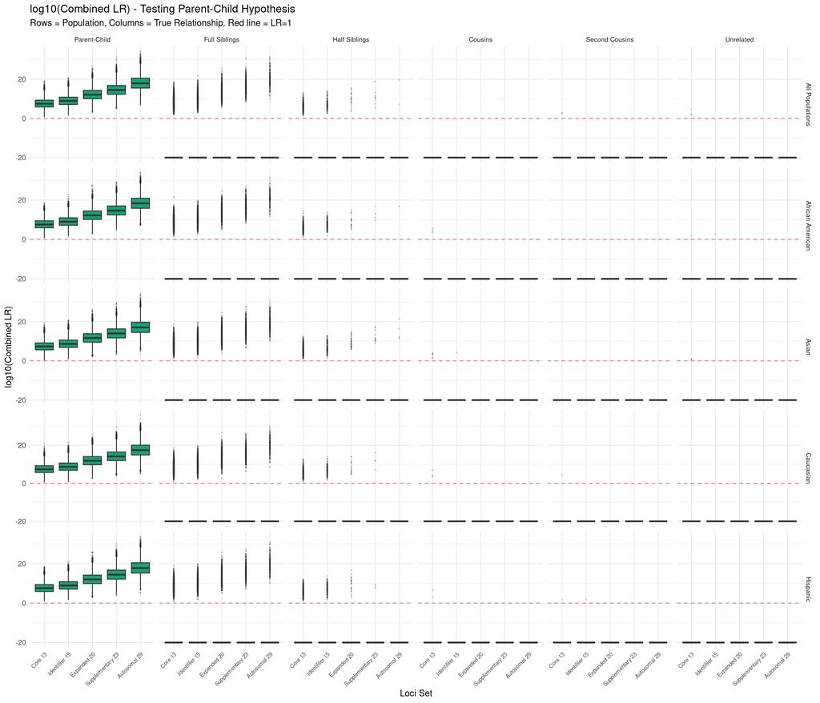

```r
subset_pc <- all_combined[tested_relationship == "parent_child"]

ggplot(subset_pc, aes(x = loci_set, y = log10_LR, fill = known_relationship)) +
  geom_boxplot(outlier.size = 0.3, outlier.alpha = 0.2) +
  facet_grid(population ~ known_relationship, scales = "free_y",
             labeller = labeller(population = population_labels,
                                 known_relationship = relationship_labels)) +
  scale_fill_manual(values = relationship_colors, guide = "none") +
  scale_x_discrete(labels = loci_set_labels) +
  geom_hline(yintercept = 0, linetype = "dashed", color = "red", alpha = 0.5) +
  labs(
    title = "log10(Combined LR) - Testing Parent-Child Hypothesis",
    subtitle = "Rows = Population, Columns = True Relationship. Red line = LR=1",
    x = "Loci Set",
    y = "log10(Combined LR)"
  ) +
  theme_minimal() +
  theme(axis.text.x = element_text(angle = 45, hjust = 1, size = 7),
        strip.text = element_text(size = 8))
```

## 3.2 Full-Siblings Hypothesis

Testing: Are these pairs full siblings vs unrelated?

### 3.2.1 All Populations Combined

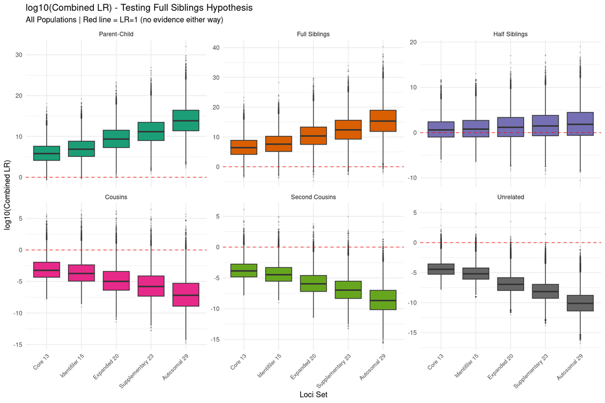

```r
plot_lr_by_hypothesis(all_combined, "full_siblings", "all")
```

### 3.2.2 By Population

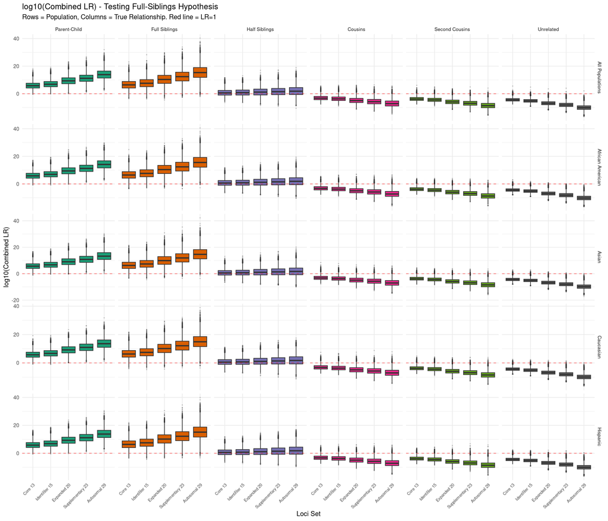

```r
subset_fs <- all_combined[tested_relationship == "full_siblings"]

ggplot(subset_fs, aes(x = loci_set, y = log10_LR, fill = known_relationship)) +
  geom_boxplot(outlier.size = 0.3, outlier.alpha = 0.2) +
  facet_grid(population ~ known_relationship, scales = "free_y",
             labeller = labeller(population = population_labels,
                                 known_relationship = relationship_labels)) +
  scale_fill_manual(values = relationship_colors, guide = "none") +
  scale_x_discrete(labels = loci_set_labels) +
  geom_hline(yintercept = 0, linetype = "dashed", color = "red", alpha = 0.5) +
  labs(
    title = "log10(Combined LR) - Testing Full-Siblings Hypothesis",
    subtitle = "Rows = Population, Columns = True Relationship. Red line = LR=1",
    x = "Loci Set",
    y = "log10(Combined LR)"
  ) +
  theme_minimal() +
  theme(axis.text.x = element_text(angle = 45, hjust = 1, size = 7),
        strip.text = element_text(size = 8))
```

## 3.3 Mean log10(LR) Summary

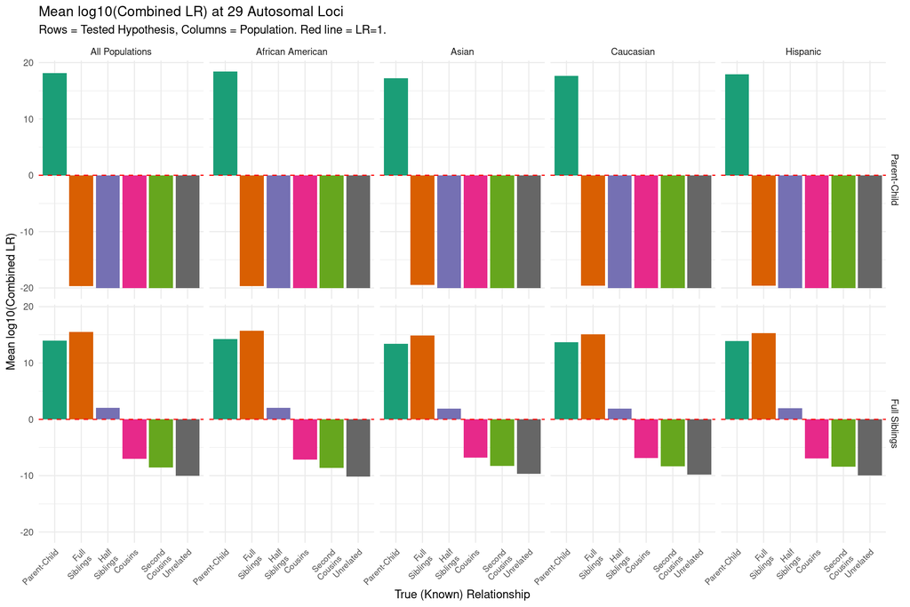

```r
# Calculate mean log10(LR) for each combination at 29 loci
lr_means <- all_combined[loci_set == "autosomal_29", .(
  mean_log10_LR = mean(log10_LR),
  sd_log10_LR = sd(log10_LR),
  n = .N
), by = .(population, known_relationship, tested_relationship)]

# Plot: facet by tested_relationship and population
ggplot(lr_means, aes(x = known_relationship, y = mean_log10_LR, fill = known_relationship)) +
  geom_col() +
  geom_hline(yintercept = 0, linetype = "dashed", color = "red") +
  facet_grid(tested_relationship ~ population,
             labeller = labeller(population = population_labels,
                                 tested_relationship = relationship_labels)) +
  scale_fill_manual(values = relationship_colors, guide = "none") +
  scale_x_discrete(labels = function(x) str_wrap(relationship_labels[x], width = 8)) +
  labs(
    title = "Mean log10(Combined LR) at 29 Autosomal Loci",
    subtitle = "Rows = Tested Hypothesis, Columns = Population. Red line = LR=1.",
    x = "True (Known) Relationship",
    y = "Mean log10(Combined LR)"
  ) +
  theme_minimal() +
  theme(axis.text.x = element_text(angle = 45, hjust = 1, size = 8),
        strip.text = element_text(size = 9))
```

```r
fwrite(lr_means, file.path(params$output_dir, "mean_log10_LR_summary.csv"))
```

**How to interpret:**

- **Bars above red line**: mean LR > 1, evidence FOR the tested hypothesis
- **Bars below red line**: mean LR < 1, evidence AGAINST the tested hypothesis
- **True positives** should have tall positive bars (e.g., full_siblings under Full-Siblings hypothesis)
- **Related false positives** may have positive bars (e.g., half-siblings under Full-Siblings hypothesis!)

# 4 Proportions Exceeding Thresholds

## 4.1 Calculate Proportions

```r
fixed_thresholds <- params$fixed_thresholds

# Calculate proportions for all combinations
proportions_all <- all_combined[, {
  props <- sapply(fixed_thresholds, function(t) mean(combined_LR > t, na.rm = TRUE))
  names(props) <- paste0("prop_LR_gt_", fixed_thresholds)
  as.list(c(n = .N, props))
}, by = .(population, known_relationship, tested_relationship, loci_set)]

proportions_all[, n_loci := loci_counts[as.character(loci_set)]]

# Add classification column
proportions_all[, classification := fcase(
  as.character(known_relationship) == as.character(tested_relationship), "True Positive",
  known_relationship == "unrelated", "Unrelated FP",
  default = "Related FP"
)]

fwrite(proportions_all, file.path(params$output_dir, "proportions_all_combinations.csv"))
```

## 4.2 Parent-Child Hypothesis: Proportion with LR > 1

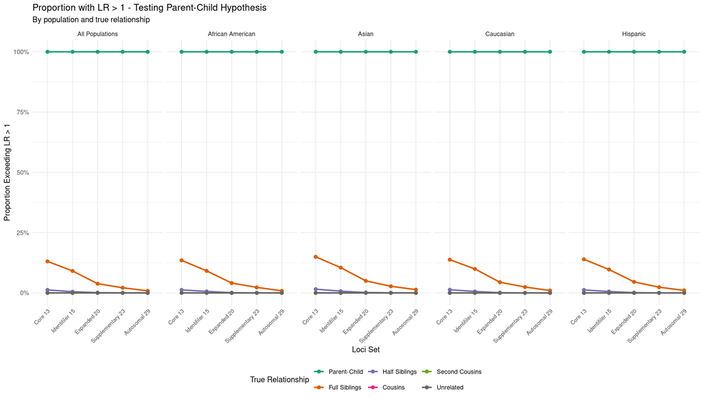

```r
plot_proportions <- function(data, tested_hyp, threshold_col = "prop_LR_gt_1") {
  subset_data <- data[tested_relationship == tested_hyp]

  ggplot(subset_data, aes(x = loci_set, y = .data[[threshold_col]],
                          color = known_relationship, group = known_relationship)) +
    geom_line(linewidth = 1) +
    geom_point(size = 2) +
    facet_wrap(~population, ncol = 5, labeller = labeller(population = population_labels)) +
    scale_color_manual(values = relationship_colors, labels = relationship_labels) +
    scale_x_discrete(labels = loci_set_labels) +
    scale_y_continuous(labels = percent_format(), limits = c(0, 1)) +
    labs(
      title = paste("Proportion with LR > 1 - Testing", relationship_labels[tested_hyp], "Hypothesis"),
      subtitle = "By population and true relationship",
      x = "Loci Set",
      y = "Proportion Exceeding LR > 1",
      color = "True Relationship"
    ) +
    theme_minimal() +
    theme(axis.text.x = element_text(angle = 45, hjust = 1, size = 8),
          legend.position = "bottom")
}

plot_proportions(proportions_all, "parent_child")
```

## 4.3 Full-Siblings Hypothesis: Proportion with LR > 1

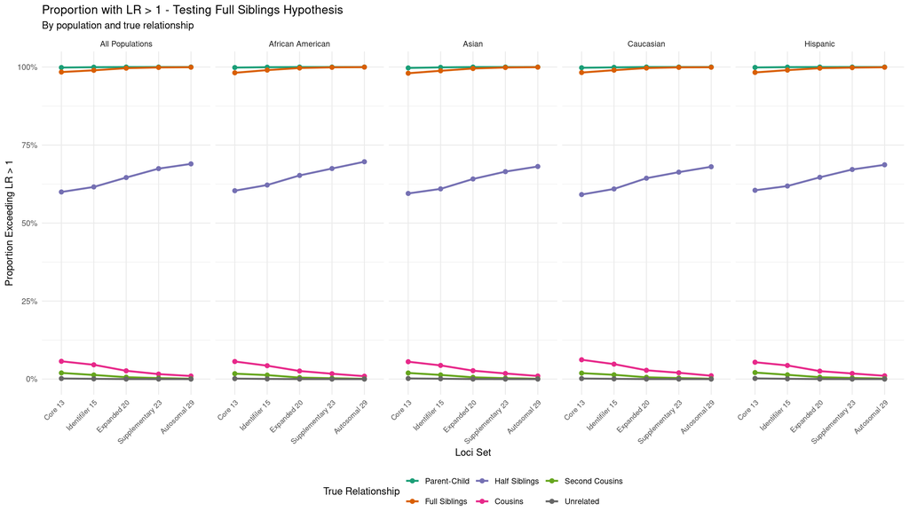

```r
plot_proportions(proportions_all, "full_siblings")
```

**Key observation:** Note whether the half-siblings line is INCREASING or DECREASING with more loci. An increasing trend means more loci → more false identifications!

## 4.4 Comparison: Parent-Child vs Full-Siblings Hypothesis

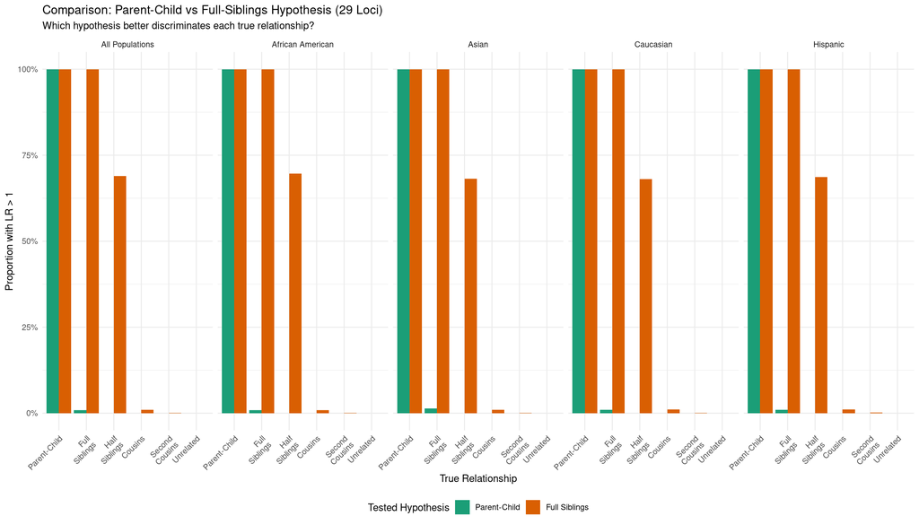

```r
compare_data <- proportions_all[loci_set == "autosomal_29"]

ggplot(compare_data, aes(x = known_relationship, y = prop_LR_gt_1,
                         fill = tested_relationship)) +
  geom_col(position = "dodge") +
  facet_wrap(~population, ncol = 5, labeller = labeller(population = population_labels)) +
  scale_fill_manual(values = c("parent_child" = "#1b9e77", "full_siblings" = "#d95f02"),
                    labels = relationship_labels) +
  scale_x_discrete(labels = function(x) str_wrap(relationship_labels[x], width = 10)) +
  scale_y_continuous(labels = percent_format()) +
  labs(
    title = "Comparison: Parent-Child vs Full-Siblings Hypothesis (29 Loci)",
    subtitle = "Which hypothesis better discriminates each true relationship?",
    x = "True Relationship",
    y = "Proportion with LR > 1",
    fill = "Tested Hypothesis"
  ) +
  theme_minimal() +
  theme(axis.text.x = element_text(angle = 45, hjust = 1),
        legend.position = "bottom")
```

# 5 Statistical Tests

## 5.1 Test 1: Effect of Loci Set (Chi-square) - By Population

**What this tests:** Does the proportion exceeding LR > 1 differ significantly across loci sets?

**Interpretation:**

- **p < 0.05 + INCREASING trend**: More loci increases the rate (good for TP, bad for FP)
- **p < 0.05 + DECREASING trend**: More loci decreases the rate (bad for TP, good for FP)
- **p >= 0.05**: No significant effect of number of loci

```r
test_loci_effect <- function(data, pop, known_rel, tested_rel, threshold_col = "prop_LR_gt_1") {
  subset <- data[population == pop & known_relationship == known_rel & tested_relationship == tested_rel]

  if (nrow(subset) < 2) return(NULL)

  n_exceed <- round(subset[[threshold_col]] * subset$n)
  n_not_exceed <- subset$n - n_exceed

  if (any(n_exceed < 0) || any(n_not_exceed < 0)) return(NULL)
  if (sum(n_exceed) == 0 || sum(n_not_exceed) == 0) return(NULL)

  contingency <- matrix(c(n_exceed, n_not_exceed), nrow = 2, byrow = TRUE,
                       dimnames = list(c("Exceed", "Not_Exceed"), as.character(subset$loci_set)))

  test_result <- tryCatch(
    chisq.test(contingency),
    error = function(e) NULL
  )

  if (is.null(test_result)) return(NULL)

  data.frame(
    population = pop,
    known_relationship = known_rel,
    tested_relationship = tested_rel,
    statistic = test_result$statistic,
    p_value = test_result$p.value,
    significant = test_result$p.value < 0.05
  )
}

# Run for all combinations
loci_tests <- rbindlist(lapply(population_order, function(pop) {
  rbindlist(lapply(relationship_order, function(known_rel) {
    rbindlist(lapply(tested_hypotheses, function(tested_rel) {
      test_loci_effect(proportions_all, pop, known_rel, tested_rel)
    }))
  }))
}))

# Display for Full-Siblings hypothesis
kable(loci_tests[tested_relationship == "full_siblings",
                 .(population, known_relationship, statistic, p_value, significant)],
      caption = "Chi-square: Loci effect on LR > 1 (Full-Siblings Hypothesis)",
      digits = c(0, 0, 2, 4, 0)) %>%
  kable_styling(bootstrap_options = c("striped", "hover"))
```

Chi-square: Loci effect on LR > 1 (Full-Siblings Hypothesis)

| population | known_relationship | statistic | p_value | significant |
| --- | --- | --- | --- | --- |
| all | parent_child | 84.46 | 0 | TRUE |
| all | full_siblings | 550.29 | 0 | TRUE |
| all | half_siblings | 504.63 | 0 | TRUE |
| all | cousins | 1055.41 | 0 | TRUE |
| all | second_cousins | 552.53 | 0 | TRUE |
| all | unrelated | 418.39 | 0 | TRUE |
| AfAm | parent_child | 86.00 | 0 | TRUE |
| AfAm | full_siblings | 712.78 | 0 | TRUE |
| AfAm | half_siblings | 502.78 | 0 | TRUE |
| AfAm | cousins | 1002.17 | 0 | TRUE |
| AfAm | second_cousins | 517.03 | 0 | TRUE |
| AfAm | unrelated | 376.24 | 0 | TRUE |
| Asian | parent_child | 147.21 | 0 | TRUE |
| Asian | full_siblings | 696.57 | 0 | TRUE |
| Asian | half_siblings | 456.83 | 0 | TRUE |
| Asian | cousins | 938.11 | 0 | TRUE |
| Asian | second_cousins | 570.53 | 0 | TRUE |
| Asian | unrelated | 451.88 | 0 | TRUE |
| Cauc | parent_child | 124.69 | 0 | TRUE |
| Cauc | full_siblings | 645.63 | 0 | TRUE |
| Cauc | half_siblings | 473.25 | 0 | TRUE |
| Cauc | cousins | 1063.75 | 0 | TRUE |
| Cauc | second_cousins | 536.65 | 0 | TRUE |
| Cauc | unrelated | 387.85 | 0 | TRUE |
| Hispanic | parent_child | 75.06 | 0 | TRUE |
| Hispanic | full_siblings | 572.03 | 0 | TRUE |
| Hispanic | half_siblings | 415.06 | 0 | TRUE |
| Hispanic | cousins | 887.83 | 0 | TRUE |
| Hispanic | second_cousins | 566.18 | 0 | TRUE |
| Hispanic | unrelated | 471.37 | 0 | TRUE |

```r
# Display for Parent-Child hypothesis
kable(loci_tests[tested_relationship == "parent_child",
                 .(population, known_relationship, statistic, p_value, significant)],
      caption = "Chi-square: Loci effect on LR > 1 (Parent-Child Hypothesis)",
      digits = c(0, 0, 2, 4, 0)) %>%
  kable_styling(bootstrap_options = c("striped", "hover"))
```

Chi-square: Loci effect on LR > 1 (Parent-Child Hypothesis)

| population | known_relationship | statistic | p_value | significant |
| --- | --- | --- | --- | --- |
| all | full_siblings | 3867.01 | 0.0000 | TRUE |
| all | half_siblings | 581.44 | 0.0000 | TRUE |
| all | second_cousins | 8.00 | 0.0916 | FALSE |
| all | unrelated | 12.00 | 0.0174 | TRUE |
| AfAm | full_siblings | 3914.61 | 0.0000 | TRUE |
| AfAm | half_siblings | 590.66 | 0.0000 | TRUE |
| AfAm | cousins | 12.00 | 0.0173 | TRUE |
| AfAm | unrelated | 3.00 | 0.5578 | FALSE |
| Asian | full_siblings | 4034.71 | 0.0000 | TRUE |
| Asian | half_siblings | 677.64 | 0.0000 | TRUE |
| Asian | cousins | 19.43 | 0.0006 | TRUE |
| Asian | unrelated | 8.00 | 0.0916 | FALSE |
| Cauc | full_siblings | 3909.78 | 0.0000 | TRUE |
| Cauc | half_siblings | 633.31 | 0.0000 | TRUE |
| Cauc | cousins | 12.00 | 0.0173 | TRUE |
| Cauc | second_cousins | 4.00 | 0.4060 | FALSE |
| Hispanic | full_siblings | 3923.35 | 0.0000 | TRUE |
| Hispanic | half_siblings | 578.37 | 0.0000 | TRUE |
| Hispanic | cousins | 8.00 | 0.0916 | FALSE |
| Hispanic | second_cousins | 3.00 | 0.5578 | FALSE |

```r
fwrite(loci_tests, file.path(params$output_dir, "stat_test_loci_effect.csv"))
```

## 5.2 Test 2: Effect of Population (Chi-square) - At 29 Loci

**What this tests:** Does the proportion exceeding LR > 1 differ across populations?

**Interpretation:**

- **p < 0.05**: Population significantly affects rates → allele frequency database matters
- **p >= 0.05**: Consistent across populations

```r
test_pop_effect <- function(data, known_rel, tested_rel, threshold_col = "prop_LR_gt_1") {
  subset <- data[known_relationship == known_rel &
                 tested_relationship == tested_rel &
                 loci_set == "autosomal_29"]

  if (nrow(subset) < 2) return(NULL)

  n_exceed <- round(subset[[threshold_col]] * subset$n)
  n_not_exceed <- subset$n - n_exceed

  if (any(n_exceed < 0) || any(n_not_exceed < 0)) return(NULL)
  if (sum(n_exceed) == 0 || sum(n_not_exceed) == 0) return(NULL)

  contingency <- matrix(c(n_exceed, n_not_exceed), nrow = 2, byrow = TRUE,
                       dimnames = list(c("Exceed", "Not_Exceed"), as.character(subset$population)))

  test_result <- tryCatch(
    chisq.test(contingency),
    error = function(e) NULL
  )

  if (is.null(test_result)) return(NULL)

  data.frame(
    known_relationship = known_rel,
    tested_relationship = tested_rel,
    statistic = test_result$statistic,
    p_value = test_result$p.value,
    significant = test_result$p.value < 0.05
  )
}

pop_tests <- rbindlist(lapply(relationship_order, function(known_rel) {
  rbindlist(lapply(tested_hypotheses, function(tested_rel) {
    test_pop_effect(proportions_all, known_rel, tested_rel)
  }))
}))

kable(pop_tests,
      caption = "Chi-square: Population effect on LR > 1 (29 Loci)",
      digits = c(0, 0, 2, 4, 0)) %>%
  kable_styling(bootstrap_options = c("striped", "hover"))
```

Chi-square: Population effect on LR > 1 (29 Loci)

| known_relationship | tested_relationship | statistic | p_value | significant |
| --- | --- | --- | --- | --- |
| full_siblings | parent_child | 32.06 | 0.0000 | TRUE |
| full_siblings | full_siblings | 4.48 | 0.3453 | FALSE |
| half_siblings | parent_child | 8.00 | 0.0916 | FALSE |
| half_siblings | full_siblings | 16.09 | 0.0029 | TRUE |
| cousins | full_siblings | 3.04 | 0.5519 | FALSE |
| second_cousins | full_siblings | 3.82 | 0.4314 | FALSE |
| unrelated | full_siblings | 2.00 | 0.7358 | FALSE |

```r
fwrite(pop_tests, file.path(params$output_dir, "stat_test_population_effect.csv"))
```

## 5.3 Test 3: Linear Trend Analysis - By Population

**What this tests:** Is there a significant linear trend in proportion as loci increase?

**Interpretation:**

| Metric | Meaning |
| --- | --- |
| **slope > 0** | Proportion INCREASES with more loci |
| **slope < 0** | Proportion DECREASES with more loci |
| **p < 0.05** | Trend is statistically significant |
| **R² > 0.8** | Very consistent linear relationship |

```r
trend_tests <- proportions_all[, {
  if (.N < 3) return(NULL)

  model <- tryCatch(lm(prop_LR_gt_1 ~ n_loci), error = function(e) NULL)
  if (is.null(model)) return(NULL)

  summary_model <- summary(model)
  coef_table <- coef(summary_model)

  if (nrow(coef_table) < 2) return(NULL)

  list(
    slope = coef_table[2, 1],
    slope_se = coef_table[2, 2],
    p_value = coef_table[2, 4],
    r_squared = summary_model$r.squared,
    trend = ifelse(coef_table[2, 1] > 0, "INCREASING", "DECREASING"),
    significant = coef_table[2, 4] < 0.05
  )
}, by = .(population, known_relationship, tested_relationship)]

# Display for full_siblings hypothesis
kable(trend_tests[tested_relationship == "full_siblings",
                  .(population, known_relationship, slope, p_value, r_squared, trend, significant)],
      caption = "Linear trend: Proportion vs N loci (Full-Siblings Hypothesis)",
      digits = c(0, 0, 5, 4, 3, 0, 0)) %>%
  kable_styling(bootstrap_options = c("striped", "hover"))
```

Linear trend: Proportion vs N loci (Full-Siblings Hypothesis)

| population | known_relationship | slope | p_value | r_squared | trend | significant |
| --- | --- | --- | --- | --- | --- | --- |
| AfAm | parent_child | 0.00009 | 0.1086 | 0.631 | INCREASING | FALSE |
| AfAm | full_siblings | 0.00105 | 0.0486 | 0.776 | INCREASING | TRUE |
| AfAm | half_siblings | 0.00584 | 0.0014 | 0.978 | INCREASING | TRUE |
| AfAm | cousins | -0.00289 | 0.0078 | 0.931 | DECREASING | TRUE |
| AfAm | second_cousins | -0.00103 | 0.0186 | 0.879 | DECREASING | TRUE |
| AfAm | unrelated | -0.00008 | 0.1016 | 0.645 | DECREASING | FALSE |
| Cauc | parent_child | 0.00013 | 0.0947 | 0.660 | INCREASING | FALSE |
| Cauc | full_siblings | 0.00100 | 0.0472 | 0.780 | INCREASING | TRUE |
| Cauc | half_siblings | 0.00566 | 0.0035 | 0.960 | INCREASING | TRUE |
| Cauc | cousins | -0.00314 | 0.0076 | 0.933 | DECREASING | TRUE |
| Cauc | second_cousins | -0.00111 | 0.0172 | 0.885 | DECREASING | TRUE |
| Cauc | unrelated | -0.00010 | 0.0730 | 0.710 | DECREASING | FALSE |
| Hispanic | parent_child | 0.00006 | 0.1494 | 0.553 | INCREASING | FALSE |
| Hispanic | full_siblings | 0.00096 | 0.0401 | 0.801 | INCREASING | TRUE |
| Hispanic | half_siblings | 0.00529 | 0.0026 | 0.966 | INCREASING | TRUE |
| Hispanic | cousins | -0.00273 | 0.0071 | 0.936 | DECREASING | TRUE |
| Hispanic | second_cousins | -0.00116 | 0.0240 | 0.857 | DECREASING | TRUE |
| Hispanic | unrelated | -0.00011 | 0.0776 | 0.699 | DECREASING | FALSE |
| Asian | parent_child | 0.00015 | 0.1030 | 0.642 | INCREASING | FALSE |
| Asian | full_siblings | 0.00116 | 0.0312 | 0.831 | INCREASING | TRUE |
| Asian | half_siblings | 0.00557 | 0.0026 | 0.966 | INCREASING | TRUE |
| Asian | cousins | -0.00284 | 0.0060 | 0.942 | DECREASING | TRUE |
| Asian | second_cousins | -0.00113 | 0.0209 | 0.869 | DECREASING | TRUE |
| Asian | unrelated | -0.00012 | 0.0578 | 0.750 | DECREASING | FALSE |
| all | parent_child | 0.00008 | 0.1174 | 0.613 | INCREASING | FALSE |
| all | full_siblings | 0.00094 | 0.0310 | 0.832 | INCREASING | TRUE |
| all | half_siblings | 0.00582 | 0.0033 | 0.961 | INCREASING | TRUE |
| all | cousins | -0.00300 | 0.0085 | 0.928 | DECREASING | TRUE |
| all | second_cousins | -0.00112 | 0.0196 | 0.875 | DECREASING | TRUE |
| all | unrelated | -0.00010 | 0.0754 | 0.704 | DECREASING | FALSE |

```r
# Display for parent_child hypothesis
kable(trend_tests[tested_relationship == "parent_child",
                  .(population, known_relationship, slope, p_value, r_squared, trend, significant)],
      caption = "Linear trend: Proportion vs N loci (Parent-Child Hypothesis)",
      digits = c(0, 0, 5, 4, 3, 0, 0)) %>%
  kable_styling(bootstrap_options = c("striped", "hover"))
```

Linear trend: Proportion vs N loci (Parent-Child Hypothesis)

| population | known_relationship | slope | p_value | r_squared | trend | significant |
| --- | --- | --- | --- | --- | --- | --- |
| AfAm | parent_child | 0.00000 | 0.2735 | 0.473 | INCREASING | FALSE |
| AfAm | full_siblings | -0.00766 | 0.0196 | 0.875 | DECREASING | TRUE |
| AfAm | half_siblings | -0.00071 | 0.0693 | 0.720 | DECREASING | FALSE |
| AfAm | cousins | -0.00001 | 0.2735 | 0.373 | DECREASING | FALSE |
| AfAm | second_cousins | 0.00000 | NaN | NaN | DECREASING | NA |
| AfAm | unrelated | 0.00000 | 0.0646 | 0.732 | DECREASING | FALSE |
| Cauc | parent_child | 0.00000 | 0.2735 | 0.473 | INCREASING | FALSE |
| Cauc | full_siblings | -0.00792 | 0.0161 | 0.890 | DECREASING | TRUE |
| Cauc | half_siblings | -0.00074 | 0.0756 | 0.704 | DECREASING | FALSE |
| Cauc | cousins | -0.00001 | 0.2735 | 0.373 | DECREASING | FALSE |
| Cauc | second_cousins | 0.00000 | 0.2735 | 0.373 | DECREASING | FALSE |
| Cauc | unrelated | 0.00000 | NaN | NaN | DECREASING | NA |
| Hispanic | parent_child | 0.00000 | 0.2735 | 0.473 | INCREASING | FALSE |
| Hispanic | full_siblings | -0.00791 | 0.0175 | 0.883 | DECREASING | TRUE |
| Hispanic | half_siblings | -0.00069 | 0.0709 | 0.716 | DECREASING | FALSE |
| Hispanic | cousins | 0.00000 | 0.2735 | 0.373 | DECREASING | FALSE |
| Hispanic | second_cousins | 0.00000 | 0.0646 | 0.732 | DECREASING | FALSE |
| Hispanic | unrelated | 0.00000 | NaN | NaN | DECREASING | NA |
| Asian | parent_child | 0.00000 | 0.2735 | 0.473 | INCREASING | FALSE |
| Asian | full_siblings | -0.00834 | 0.0183 | 0.880 | DECREASING | TRUE |
| Asian | half_siblings | -0.00086 | 0.0711 | 0.715 | DECREASING | FALSE |
| Asian | cousins | -0.00001 | 0.1848 | 0.495 | DECREASING | FALSE |
| Asian | second_cousins | 0.00000 | NaN | NaN | DECREASING | NA |
| Asian | unrelated | 0.00000 | 0.2735 | 0.373 | DECREASING | FALSE |
| all | parent_child | 0.00000 | 0.2735 | 0.473 | INCREASING | FALSE |
| all | full_siblings | -0.00750 | 0.0202 | 0.872 | DECREASING | TRUE |
| all | half_siblings | -0.00067 | 0.0873 | 0.677 | DECREASING | FALSE |
| all | cousins | 0.00000 | NaN | NaN | DECREASING | NA |
| all | second_cousins | 0.00000 | 0.2735 | 0.373 | DECREASING | FALSE |
| all | unrelated | 0.00000 | 0.2735 | 0.373 | DECREASING | FALSE |

```r
fwrite(trend_tests, file.path(params$output_dir, "stat_test_trend.csv"))
```

**Critical finding:** If half_siblings under Full-Siblings hypothesis shows: - trend = “INCREASING” - significant = TRUE

This confirms that **more loci increases the rate at which half-siblings are falsely identified as full siblings**.

# 6 Classification Performance

## 6.1 Summary at 29 Loci

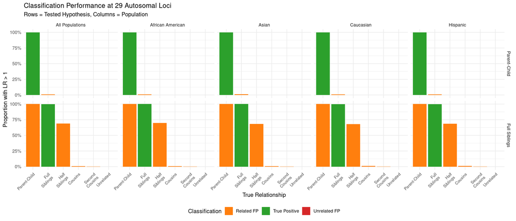

```r
summary_29 <- proportions_all[loci_set == "autosomal_29"]

ggplot(summary_29, aes(x = known_relationship, y = prop_LR_gt_1, fill = classification)) +
  geom_col(position = "dodge") +
  facet_grid(tested_relationship ~ population,
             labeller = labeller(population = population_labels,
                                 tested_relationship = relationship_labels)) +
  scale_fill_manual(values = c("True Positive" = "#2ca02c",
                               "Related FP" = "#ff7f0e",
                               "Unrelated FP" = "#d62728")) +
  scale_x_discrete(labels = function(x) str_wrap(relationship_labels[x], width = 8)) +
  scale_y_continuous(labels = percent_format()) +
  labs(
    title = "Classification Performance at 29 Autosomal Loci",
    subtitle = "Rows = Tested Hypothesis, Columns = Population",
    x = "True Relationship",
    y = "Proportion with LR > 1",
    fill = "Classification"
  ) +
  theme_minimal() +
  theme(axis.text.x = element_text(angle = 45, hjust = 1, size = 8),
        legend.position = "bottom")
```

```r
ggsave(file.path(params$output_dir, "classification_summary.png"), width = 14, height = 6, dpi = 300)
```

## 6.2 Detailed Rates Table

```r
rates_table <- proportions_all[
  loci_set == "autosomal_29",
  .(population, known_relationship, tested_relationship, classification,
    prop_LR_gt_1, prop_LR_gt_10, prop_LR_gt_100, prop_LR_gt_1000)
]

setorder(rates_table, tested_relationship, population, classification, known_relationship)

kable(rates_table,
      caption = "Detailed rates at 29 Autosomal Loci",
      digits = 4) %>%
  kable_styling(bootstrap_options = c("striped", "hover"), font_size = 10) %>%
  scroll_box(height = "500px")
```

Detailed rates at 29 Autosomal Loci

| population | known_relationship | tested_relationship | classification | prop_LR_gt_1 | prop_LR_gt_10 | prop_LR_gt_100 | prop_LR_gt_1000 |
| --- | --- | --- | --- | --- | --- | --- | --- |
| all | full_siblings | parent_child | Related FP | 0.0086 | 0.0086 | 0.0086 | 0.0086 |
| all | half_siblings | parent_child | Related FP | 0.0001 | 0.0001 | 0.0001 | 0.0001 |
| all | cousins | parent_child | Related FP | 0.0000 | 0.0000 | 0.0000 | 0.0000 |
| all | second_cousins | parent_child | Related FP | 0.0000 | 0.0000 | 0.0000 | 0.0000 |
| all | parent_child | parent_child | True Positive | 1.0000 | 1.0000 | 1.0000 | 1.0000 |
| all | unrelated | parent_child | Unrelated FP | 0.0000 | 0.0000 | 0.0000 | 0.0000 |
| AfAm | full_siblings | parent_child | Related FP | 0.0086 | 0.0086 | 0.0086 | 0.0086 |
| AfAm | half_siblings | parent_child | Related FP | 0.0000 | 0.0000 | 0.0000 | 0.0000 |
| AfAm | cousins | parent_child | Related FP | 0.0000 | 0.0000 | 0.0000 | 0.0000 |
| AfAm | second_cousins | parent_child | Related FP | 0.0000 | 0.0000 | 0.0000 | 0.0000 |
| AfAm | parent_child | parent_child | True Positive | 1.0000 | 1.0000 | 1.0000 | 1.0000 |
| AfAm | unrelated | parent_child | Unrelated FP | 0.0000 | 0.0000 | 0.0000 | 0.0000 |
| Asian | full_siblings | parent_child | Related FP | 0.0135 | 0.0135 | 0.0135 | 0.0135 |
| Asian | half_siblings | parent_child | Related FP | 0.0002 | 0.0002 | 0.0002 | 0.0002 |
| Asian | cousins | parent_child | Related FP | 0.0000 | 0.0000 | 0.0000 | 0.0000 |
| Asian | second_cousins | parent_child | Related FP | 0.0000 | 0.0000 | 0.0000 | 0.0000 |
| Asian | parent_child | parent_child | True Positive | 1.0000 | 1.0000 | 1.0000 | 1.0000 |
| Asian | unrelated | parent_child | Unrelated FP | 0.0000 | 0.0000 | 0.0000 | 0.0000 |
| Cauc | full_siblings | parent_child | Related FP | 0.0098 | 0.0098 | 0.0098 | 0.0098 |
| Cauc | half_siblings | parent_child | Related FP | 0.0000 | 0.0000 | 0.0000 | 0.0000 |
| Cauc | cousins | parent_child | Related FP | 0.0000 | 0.0000 | 0.0000 | 0.0000 |
| Cauc | second_cousins | parent_child | Related FP | 0.0000 | 0.0000 | 0.0000 | 0.0000 |
| Cauc | parent_child | parent_child | True Positive | 1.0000 | 1.0000 | 1.0000 | 1.0000 |
| Cauc | unrelated | parent_child | Unrelated FP | 0.0000 | 0.0000 | 0.0000 | 0.0000 |
| Hispanic | full_siblings | parent_child | Related FP | 0.0103 | 0.0103 | 0.0103 | 0.0103 |
| Hispanic | half_siblings | parent_child | Related FP | 0.0000 | 0.0000 | 0.0000 | 0.0000 |
| Hispanic | cousins | parent_child | Related FP | 0.0000 | 0.0000 | 0.0000 | 0.0000 |
| Hispanic | second_cousins | parent_child | Related FP | 0.0000 | 0.0000 | 0.0000 | 0.0000 |
| Hispanic | parent_child | parent_child | True Positive | 1.0000 | 1.0000 | 1.0000 | 1.0000 |
| Hispanic | unrelated | parent_child | Unrelated FP | 0.0000 | 0.0000 | 0.0000 | 0.0000 |
| all | parent_child | full_siblings | Related FP | 1.0000 | 1.0000 | 1.0000 | 0.9998 |
| all | half_siblings | full_siblings | Related FP | 0.6896 | 0.5859 | 0.4828 | 0.3804 |
| all | cousins | full_siblings | Related FP | 0.0098 | 0.0040 | 0.0018 | 0.0008 |
| all | second_cousins | full_siblings | Related FP | 0.0012 | 0.0003 | 0.0001 | 0.0000 |
| all | full_siblings | full_siblings | True Positive | 0.9994 | 0.9984 | 0.9972 | 0.9950 |
| all | unrelated | full_siblings | Unrelated FP | 0.0000 | 0.0000 | 0.0000 | 0.0000 |
| AfAm | parent_child | full_siblings | Related FP | 1.0000 | 1.0000 | 1.0000 | 0.9999 |
| AfAm | half_siblings | full_siblings | Related FP | 0.6966 | 0.5958 | 0.4879 | 0.3840 |
| AfAm | cousins | full_siblings | Related FP | 0.0092 | 0.0041 | 0.0018 | 0.0009 |
| AfAm | second_cousins | full_siblings | Related FP | 0.0009 | 0.0004 | 0.0002 | 0.0000 |
| AfAm | full_siblings | full_siblings | True Positive | 0.9996 | 0.9992 | 0.9980 | 0.9957 |
| AfAm | unrelated | full_siblings | Unrelated FP | 0.0000 | 0.0000 | 0.0000 | 0.0000 |
| Asian | parent_child | full_siblings | Related FP | 1.0000 | 0.9999 | 0.9998 | 0.9992 |
| Asian | half_siblings | full_siblings | Related FP | 0.6813 | 0.5784 | 0.4700 | 0.3663 |
| Asian | cousins | full_siblings | Related FP | 0.0099 | 0.0041 | 0.0018 | 0.0006 |
| Asian | second_cousins | full_siblings | Related FP | 0.0011 | 0.0004 | 0.0001 | 0.0000 |
| Asian | full_siblings | full_siblings | True Positive | 0.9996 | 0.9986 | 0.9964 | 0.9934 |
| Asian | unrelated | full_siblings | Unrelated FP | 0.0000 | 0.0000 | 0.0000 | 0.0000 |
| Cauc | parent_child | full_siblings | Related FP | 1.0000 | 1.0000 | 0.9999 | 0.9993 |
| Cauc | half_siblings | full_siblings | Related FP | 0.6805 | 0.5748 | 0.4726 | 0.3715 |
| Cauc | cousins | full_siblings | Related FP | 0.0108 | 0.0055 | 0.0024 | 0.0009 |
| Cauc | second_cousins | full_siblings | Related FP | 0.0012 | 0.0006 | 0.0003 | 0.0001 |
| Cauc | full_siblings | full_siblings | True Positive | 0.9992 | 0.9984 | 0.9969 | 0.9940 |
| Cauc | unrelated | full_siblings | Unrelated FP | 0.0000 | 0.0000 | 0.0000 | 0.0000 |
| Hispanic | parent_child | full_siblings | Related FP | 1.0000 | 1.0000 | 1.0000 | 0.9998 |
| Hispanic | half_siblings | full_siblings | Related FP | 0.6868 | 0.5866 | 0.4777 | 0.3796 |
| Hispanic | cousins | full_siblings | Related FP | 0.0106 | 0.0046 | 0.0018 | 0.0008 |
| Hispanic | second_cousins | full_siblings | Related FP | 0.0015 | 0.0010 | 0.0006 | 0.0001 |
| Hispanic | full_siblings | full_siblings | True Positive | 0.9992 | 0.9985 | 0.9971 | 0.9942 |
| Hispanic | unrelated | full_siblings | Unrelated FP | 0.0000 | 0.0000 | 0.0000 | 0.0000 |

```r
fwrite(rates_table, file.path(params$output_dir, "detailed_rates_29loci.csv"))
```

# 7 Key Findings

```r
cat("=== KEY FINDINGS ===\n\n")
```

```
## === KEY FINDINGS ===
```

```r
cat("1. TRUE POSITIVE RATES (at 29 loci, LR > 1):\n")
```

```
## 1. TRUE POSITIVE RATES (at 29 loci, LR > 1):
```

```r
tp_rates <- proportions_all[loci_set == "autosomal_29" &
                            as.character(known_relationship) == as.character(tested_relationship),
                            .(population, tested_relationship, prop_LR_gt_1)]
print(dcast(tp_rates, tested_relationship ~ population, value.var = "prop_LR_gt_1"))
```

```
## Key: <tested_relationship>
##    tested_relationship     all    AfAm   Asian    Cauc Hispanic
##                 <fctr>   <num>   <num>   <num>   <num>    <num>
## 1:        parent_child 1.00000 1.00000 1.00000 1.00000  1.00000
## 2:       full_siblings 0.99935 0.99965 0.99955 0.99925  0.99925
```

```r
cat("\n2. UNRELATED FALSE POSITIVE RATES (at 29 loci, LR > 1):\n")
```

```
##
## 2. UNRELATED FALSE POSITIVE RATES (at 29 loci, LR > 1):
```

```r
unrel_fp <- proportions_all[loci_set == "autosomal_29" &
                            known_relationship == "unrelated",
                            .(population, tested_relationship, prop_LR_gt_1)]
print(dcast(unrel_fp, tested_relationship ~ population, value.var = "prop_LR_gt_1"))
```

```
## Key: <tested_relationship>
##    tested_relationship   all  AfAm Asian  Cauc Hispanic
##                 <fctr> <num> <num> <num> <num>    <num>
## 1:        parent_child 0e+00     0 0e+00 0e+00    0e+00
## 2:       full_siblings 1e-05     0 1e-05 1e-05    2e-05
```

```r
# More detailed unrelated FP breakdown
cat("\n2b. DETAILED UNRELATED FALSE POSITIVE BREAKDOWN:\n")
```

```
##
## 2b. DETAILED UNRELATED FALSE POSITIVE BREAKDOWN:
```

```r
unrel_detailed <- proportions_all[loci_set == "autosomal_29" &
                                  known_relationship == "unrelated",
                                  .(population, tested_relationship,
                                    n,
                                    fp_count = round(prop_LR_gt_1 * n),
                                    fp_rate_pct = prop_LR_gt_1 * 100)]
print(unrel_detailed)
```

```
##     population tested_relationship     n fp_count fp_rate_pct
##         <fctr>              <fctr> <num>    <num>       <num>
##  1:       AfAm       full_siblings 1e+05        0       0.000
##  2:       AfAm        parent_child 1e+05        0       0.000
##  3:       Cauc       full_siblings 1e+05        1       0.001
##  4:       Cauc        parent_child 1e+05        0       0.000
##  5:   Hispanic       full_siblings 1e+05        2       0.002
##  6:   Hispanic        parent_child 1e+05        0       0.000
##  7:      Asian       full_siblings 1e+05        1       0.001
##  8:      Asian        parent_child 1e+05        0       0.000
##  9:        all       full_siblings 1e+05        1       0.001
## 10:        all        parent_child 1e+05        0       0.000
```

```r
cat("\nOverall FP summary:\n")
```

```
##
## Overall FP summary:
```

```r
overall_summary <- unrel_detailed[, .(
  total_tests = sum(n),
  total_fps = sum(fp_count),
  overall_fp_pct = sum(fp_count) / sum(n) * 100
), by = tested_relationship]
print(overall_summary)
```

```
##    tested_relationship total_tests total_fps overall_fp_pct
##                 <fctr>       <num>     <num>          <num>
## 1:       full_siblings       5e+05         5          0.001
## 2:        parent_child       5e+05         0          0.000
```

```r
cat("\n3. HALF-SIBLING AS FULL-SIBLING FALSE ID (at 29 loci):\n")
```

```
##
## 3. HALF-SIBLING AS FULL-SIBLING FALSE ID (at 29 loci):
```

```r
hs_fp <- proportions_all[loci_set == "autosomal_29" &
                         known_relationship == "half_siblings" &
                         tested_relationship == "full_siblings",
                         .(population, prop_LR_gt_1, prop_LR_gt_10, prop_LR_gt_100)]
print(hs_fp)
```

```
##    population prop_LR_gt_1 prop_LR_gt_10 prop_LR_gt_100
##        <fctr>        <num>         <num>          <num>
## 1:       AfAm      0.69655       0.59580        0.48790
## 2:       Cauc      0.68050       0.57475        0.47260
## 3:   Hispanic      0.68675       0.58660        0.47770
## 4:      Asian      0.68130       0.57835        0.46995
## 5:        all      0.68965       0.58590        0.48280
```

```r
cat("\n4. TREND DIRECTIONS (Full-Siblings hypothesis, half-siblings):\n")
```

```
##
## 4. TREND DIRECTIONS (Full-Siblings hypothesis, half-siblings):
```

```r
hs_trend <- trend_tests[tested_relationship == "full_siblings" & known_relationship == "half_siblings"]
print(hs_trend[, .(population, trend, slope, p_value, significant)])
```

```
##    population      trend       slope     p_value significant
##        <fctr>     <char>       <num>       <num>      <lgcl>
## 1:       AfAm INCREASING 0.005840244 0.001396284        TRUE
## 2:       Cauc INCREASING 0.005657012 0.003450075        TRUE
## 3:   Hispanic INCREASING 0.005289329 0.002634744        TRUE
## 4:      Asian INCREASING 0.005574390 0.002634325        TRUE
## 5:        all INCREASING 0.005817378 0.003338649        TRUE
```

# 8 Interpretation Summary

## 8.1 Quick Reference

| What to Check | Good Sign | Concerning Sign |
| --- | --- | --- |
| True Positive Rate | High (>90%) and increasing with loci | Low or decreasing |
| Unrelated FP Rate | Low (<5%) and decreasing with loci | High or increasing |
| Related FP Rate (e.g., half-sibs) | Low and decreasing with loci | High and INCREASING |
| Population effect | Not significant | Highly significant |

## 8.2 Key Questions Answered

1. **Does adding more loci help?**
   - For true positives: YES (should increase)
   - For unrelated FP: YES (should decrease)
   - For related FP like half-siblings: DEPENDS on the relationship
2. **Are results consistent across populations?**
   - Check the population effect chi-square tests
   - Significant = ancestry matters for this relationship
3. **Which hypothesis is better for discrimination?**
   - Compare the classification summary plot

# 9 Session Info

```r
cat("Analysis completed:", format(Sys.time(), "%Y-%m-%d %H:%M:%S"), "\n")
```

```
## Analysis completed: 2026-01-16 13:22:28
```

```r
cat("Output directory:", params$output_dir, "\n\n")
```

```
## Output directory: ../output/lr_analysis_20251219/analysis_results
```

```r
output_files <- list.files(params$output_dir, full.names = FALSE)
cat("Generated files:\n")
```

```
## Generated files:
```

```r
cat(paste(" -", output_files), sep = "\n")
```

```
##  - classification_summary.png
##  - detailed_rates_29loci.csv
##  - mean_log10_LR_summary.csv
##  - proportions_all_combinations.csv
##  - stat_test_loci_effect.csv
##  - stat_test_population_effect.csv
##  - stat_test_trend.csv
```